# **Optional** Online advertising natural experiment.

[output not shown]

```r
library(data.table)
d <- fread('../data/yahoo_data.csv')
```

[output not shown]

```r
setnames(
  d,
  old = c('total_ad_exposures_week1', 'treatment_ad_exposures_week1'),
  new = c('total_ads', 'treatment_ads')
)
```

```r
head(d)
```

```
##    product_b total_ads treatment_ads week0 week1 week2 week3 week4 week5 week6
##        <int>     <int>         <int> <num> <num> <num> <num> <num> <num> <num>
## 1:         1         4             3   5.5   6.2   0.0   0.0   0.0   0.0   0.0
## 2:         1         1             1   6.2   0.0   8.6   2.4   0.0   7.4   0.0
## 3:         1         3             1   0.0   5.3   0.0   8.1   7.8   3.3   0.0
## 4:         0         5             0   0.0   4.1   0.0   8.8   5.8   5.9   0.0
## 5:         0         1             1   7.6   3.6   4.6   5.5   7.2   7.1   0.0
## 6:         1         4             4   6.3   5.5   9.8   5.0   0.0   0.0   7.7
##    week7 week8 week9 week10
##    <num> <num> <num>  <num>
## 1:     0   9.7   4.1    0.0
## 2:     0   0.0   5.7    0.0
## 3:     0   9.4   0.0    0.0
## 4:     0   0.0   9.6    0.0
## 5:     0   0.0   0.0    0.0
## 6:     0  11.0   4.8    6.9
```

## Cross table of total_ads and treatment_ads

A. Run a crosstab – which in R is `table` – of `total_ads` and `treatment_ads` to sanity check that the distribution of impressions looks as it should. After you write your code, write a few narrative sentences about whether this distribution looks reasonable. Why does it look like this? (No computation required here, just a brief verbal response.)

```r
# Creating the cross tab
cross_tab <- table(d$total_ads, d$treatment_ads)
cross_tab
```

```
##
##         0     1     2     3     4     5     6
##   0 61182     0     0     0     0     0     0
##   1 36754 37215     0     0     0     0     0
##   2 21143 42036 20965     0     0     0     0
##   3 10683 32073 32314 10726     0     0     0
##   4  5044 20003 30432 20223  5115     0     0
##   5  2045 10563 20970 20793 10293  2131     0
##   6   729  4437 10977 14771 11147  4486   750
```

**Answer:** The table has an upper-triangular structure that reflects the fact that the number of treatment ads never exceeds the total number of homepage visits. Users tend to have treatment exposures distributed roughly symmetrically around half of their total visits, following a binomial pattern that reflects the quasi-random (Bernoulli) assignment of ads to even-second homepage visits.

## Placebo test

A colleague of yours proposes to estimate the following model: `d[ , lm(week1 ~ tretment_ads)]` You are suspicious. Run a placebo test with `week0` purchases as the outcome and report the results. Since treatment is applied in week 1, and `week0` is purchases in week 0, *should* there be an relationship? Did the placebo test “succeed” or “fail”? Why do you say so?

```r
# Creating placebo regression
model_colleague <- lm(week0 ~ treatment_ads, data = d)
summary(model_colleague)
```

```
##
## Call:
## lm(formula = week0 ~ treatment_ads, data = d)
##
## Residuals:
##    Min     1Q Median     3Q    Max
## -3.248 -2.196 -1.670  2.430  8.330
##
## Coefficients:
##               Estimate Std. Error t value Pr(>|t|)
## (Intercept)   1.669685   0.006027   277.0   <2e-16 ***
## treatment_ads 0.263099   0.003155    83.4   <2e-16 ***
## ---
## Signif. codes:  0 '***' 0.001 '**' 0.01 '*' 0.05 '.' 0.1 ' ' 1
##
## Residual standard error: 2.796 on 499998 degrees of freedom
## Multiple R-squared:  0.01372,    Adjusted R-squared:  0.01372
## F-statistic:  6955 on 1 and 499998 DF,  p-value: < 2.2e-16
```

**Answer:** The placebo regression of `week0` on `treatment_ads` yields a coefficient of 0.2631 with a p-value of 0. Since treatment is applied starting in week 1, there should be no causal effect on week 0 purchases. The fact that the coefficient is positive and highly significant indicates that users with more treatment exposures already had higher baseline spending. Therefore, the placebo test fails and suggests that the treatment assignment is correlated with pre-existing differences in purchasing behavior and that simple regressions of `week1` on `treatment_ads` could lead to biased estimates of the treatment effect.

## What has gone wrong?

Here’s the tip off: the placebo test suggests that there is something wrong with our experiment (i.e. the randomization isn’t working) or our data analysis. We suggest looking for a problem with the data analysis. Do you see something that might be spoiling the “randomness” of the treatment variable? (Hint: it should be present in the cross-tab that you wrote in the first part of this qusetion.) How can you improve your analysis to address this problem? Why does the placebo test turn out the way it does? What one thing needs to be done to analyze the data correctly? Please provide a brief explanation of why, not just what needs to be done.

**Answer:** From the cross-tab, we can see that users with more total homepage visits inherently tend to have more treatment exposures. This means that `treatment_ads` is mechanically correlated with `total_ads`, which is itself correlated with week 0 purchasing behavior. Users who have more homepage visits during the campaign week (and thusly higher `total_ads`) are more likely to have higher treatment exposures (`treatment_ads`) and also had a higher baseline spending in week 0. Therefore, regressing `week0` on `treatment_ads` picks up the pre-existing correlation despite there being no treatment applied yet. If we adjust for total visits by including `total_ads` as a covariate in the regression, the mechanical correlation between the treatment and baseline purchase behavior will be removed.

## Conduct proposed solution and re-evaluate placebo test

Implement the procedure you propose from part 3, run the placebo test for the Week 0 data again, and report the results. (This placebo test should pass; if it does not, re-evaluate your strategy before wasting time proceeding.) How can you tell this this has fixed the problem? Is it possible, even though this test now passes, that there is still some other problem?

```r
# Creating regression that integrates `total_ads` as the covariate
model_passes_placebo <- lm(week0 ~ treatment_ads + total_ads, data = d)
summary(model_passes_placebo)
```

```
##
## Call:
## lm(formula = week0 ~ treatment_ads + total_ads, data = d)
##
## Residuals:
##    Min     1Q Median     3Q    Max
## -2.817 -2.079 -1.589  2.455  7.823
##
## Coefficients:
##                Estimate Std. Error t value Pr(>|t|)
## (Intercept)    1.345375   0.007295 184.436   <2e-16 ***
## treatment_ads -0.002245   0.004629  -0.485    0.628
## total_ads      0.245348   0.003149  77.922   <2e-16 ***
## ---
## Signif. codes:  0 '***' 0.001 '**' 0.01 '*' 0.05 '.' 0.1 ' ' 1
##
## Residual standard error: 2.779 on 499997 degrees of freedom
## Multiple R-squared:  0.02555,    Adjusted R-squared:  0.02555
## F-statistic:  6556 on 2 and 499997 DF,  p-value: < 2.2e-16
```

**Answer:** The coefficient on treatment_ads is -0.0022 with an insignificant p-value of 0.6276. This coefficient is effectively zero (in addition to being statistically insignificant), which indicates that once we account for total homepage visits, there is no longer a confounding relationship between treatment exposures and baseline purchase behavior. While this specific issue has been remedied, it is still possible that there are other confounding variables or the possibility of nonlinear treatment effects.

## Estimate treatment effect with proposed solution

Now estimate the causal effect of each ad exposure on purchases during Week 1. You should use the same technique that passed the placebo test in part 4. Describe how, if at all, the treatment estimate that your model produces changes from the estimate that your colleague produced.

```r
model_causal <- lm(week1 ~ treatment_ads + total_ads, data = d)
summary(model_causal)
```

```
##
## Call:
## lm(formula = week1 ~ treatment_ads + total_ads, data = d)
##
## Residuals:
##    Min     1Q Median     3Q    Max
## -3.003 -2.104 -1.542  2.447  8.110
##
## Coefficients:
##               Estimate Std. Error t value Pr(>|t|)
## (Intercept)   1.317960   0.007263  181.47   <2e-16 ***
## treatment_ads 0.056340   0.004609   12.22   <2e-16 ***
## total_ads     0.224478   0.003135   71.61   <2e-16 ***
## ---
## Signif. codes:  0 '***' 0.001 '**' 0.01 '*' 0.05 '.' 0.1 ' ' 1
##
## Residual standard error: 2.767 on 499997 degrees of freedom
## Multiple R-squared:  0.02782,    Adjusted R-squared:  0.02781
## F-statistic:  7153 on 2 and 499997 DF,  p-value: < 2.2e-16
```

## Defend you method

Upon seeing these results, the colleague who proposed the specification that did not pass the placeo test challenges your results – they make the campaign look less successful! Write a short paragraph (i.e. 4-6 sentences) that argues for why your estimation strategy is better positioned to estimate a causal effect.

**Answer:** While the colleague’s model suggested a larger effect of `treatment_ads`, it fails to account for the fact that users with more homepage visits naturally receive more treatment exposures and also tend to spend more even before the campaign begins. In contrast, our estimation strategy adjusts for total homepage visits (total_ads) which isolates the variation in treatment ads that is independent of visit frequency. Since our specification passed the placebo test on week 0 purchases, we have shown that pre-campaign spending is no longer correlated with the treatment variable. By controlling for total visits, our approach yields a less biased, more accurate estimate of the causal effect of each ad exposure on week 1 purchases. Therefore, while the adjusted effect appears smaller, it more faithfully represents the true causal impact of the advertising campaign.

## Intertemporal substitution?

One concern raised by David Reiley is that advertisements might just shift *when* people purchase something – rather than increasing the total amount they purchase. Given the data that you have available to you, can you propose a method of evaluating this concern? Estimate the model that you propose, and describe your findings.

```r
# Defining a cumulative revenue variable
d$cumulative_week_1_10 <- rowSums(d[, paste0("week", 1:10)])
```

```r
# Create cumulative model
model_overall <- lm(cumulative_week_1_10 ~ treatment_ads + total_ads, data = d)
summary(model_overall)
```

```
##
## Call:
## lm(formula = cumulative_week_1_10 ~ treatment_ads + total_ads,
##     data = d)
##
## Residuals:
##     Min      1Q  Median      3Q     Max
## -30.597  -7.372  -0.731   6.654  59.782
##
## Coefficients:
##               Estimate Std. Error t value Pr(>|t|)
## (Intercept)   17.15081    0.02771 618.949   <2e-16 ***
## treatment_ads  0.01274    0.01758   0.724    0.469
## total_ads      2.22834    0.01196 186.307   <2e-16 ***
## ---
## Signif. codes:  0 '***' 0.001 '**' 0.01 '*' 0.05 '.' 0.1 ' ' 1
##
## Residual standard error: 10.56 on 499997 degrees of freedom
## Multiple R-squared:  0.1321, Adjusted R-squared:  0.1321
## F-statistic: 3.804e+04 on 2 and 499997 DF,  p-value: < 2.2e-16
```

**Answer:** The cumulative model yields a coefficient on treatment_ads of 0.0127 with a p-value of 0.4688. This coefficient is small and statistically insignificant, indicating that additional treatment ads do not significantly increase total spending over the ten weeks following the campaign. Comparing these results to the week 1 model (`model_causal`), where `treatment_ads` had a statistically significant positive effect, suggests that the campaign mainly accelerates purchases into week 1 rather than generating additional spending overall. This can be interpreted as the ads shifting the timing of purchases rather than increasing total revenue.

## Weekly effects

If you look at purchases in each week – one regression estimated for each outcome from week 1 through week 10 (that’s 10 regression in a row) – what is the relationship between treatment ads and purchases in each of those weeks. This is now ranging into exploring data with models – how many have we run in this question alone!? – so consider whether a plot might help make whatever relationship exists more clear.

```r
library(ggplot2)

# Running one regression per week and storing results
weeks <- paste0("week", 1:10)
coef_treat <- numeric(length(weeks))
se_treat <- numeric(length(weeks))

for(i in seq_along(weeks)) {
  model <- lm(as.formula(paste(weeks[i], "~ treatment_ads + total_ads")), data = d)
  coef_treat[i] <- coef(model)["treatment_ads"]
  se_treat[i] <- summary(model)$coefficients["treatment_ads", "Std. Error"]
}
```

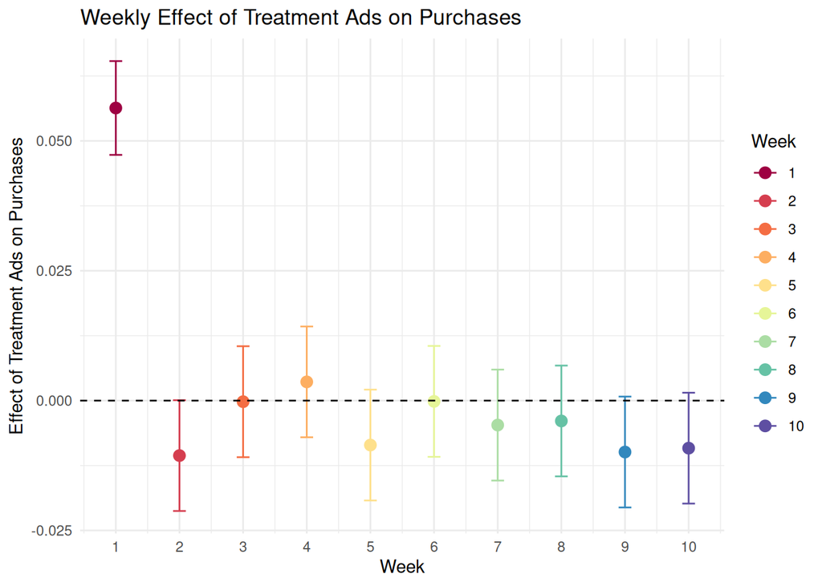

```r
# Creating data frame for plotting
plot_data <- data.frame(
  week = 1:10,
  coef = coef_treat,
  lower = coef_treat - 1.96 * se_treat,
  upper = coef_treat + 1.96 * se_treat
)

# Plotting treatment effect over time
ggplot(plot_data, aes(x = week, y = coef, color = factor(week))) +
  geom_point(size = 3) +
  geom_errorbar(aes(ymin = lower, ymax = upper), width = 0.2) +
  geom_hline(yintercept = 0, linetype = "dashed") +
  scale_x_continuous(breaks = 1:10) +
  scale_color_brewer(palette = "Spectral") +
  labs(x = "Week",
       y = "Effect of Treatment Ads on Purchases",
       color = "Week",
       title = "Weekly Effect of Treatment Ads on Purchases") +
  theme_minimal()
```

**Answer:** We create a plot of `treatment_ads` coefficient estimates and 95% confidence intervals per week, where confidence intervals straddling 0 indicated statistically insignificant estimates. From the plot, we can see that week 1 sees a positive and statistically significant coefficient, showing that treatment ads increase purchases during this week. However, all of weeks 2-10 have statistically insignificant coefficients near 0. Together, these results suggest that treatment ads mainly accelerate purchases into week 1, rather than increasing overall spending throughout weeks 1-10.

## Evaluating what is happening in the data

I. What might explain this pattern in your data. Stay curious when you’re writing models! But, also be clear that we’re fitting a **lot** of models and making up a theory/explanation after the fact.

**Answer:** The observed pattern of a positive effect in week 1, but near-zero effects in weeks 2–10, could indicate a timing-shift where ads accelerate purchases that would have otherwise occurred later. This suggests that users respond immediately to ads, concentrating revenue in the campaign week rather than increasing overall spending. Other factors such as seasonality or user heterogeneity could also contribute to these results, so further analysis would be needed to confirm the specific mechanism at play.

## Evaluate whether there are non-linear relationships

We started by making the assumption that there was a linear relationship between the treatment ads and purchases. What other types of relationships might exist? After you propose at least two additional non-linear relationships, write a model that estimates these, and write a test for whether these non-linear effects you’ve proposed produce models that fit the data better than the linear model.

```r
# Creating a quadratic model
model_quadratic <- lm(week1 ~ treatment_ads + I(treatment_ads^2) + total_ads, data = d)
quad_summary <- summary(model_quadratic)

# Creating logarithmic model
model_log <- lm(week1 ~ log(1 + treatment_ads) + total_ads, data = d)
log_summary <- summary(model_log)

quad_summary
```

```
##
## Call:
## lm(formula = week1 ~ treatment_ads + I(treatment_ads^2) + total_ads,
##     data = d)
##
## Residuals:
##    Min     1Q Median     3Q    Max
## -2.977 -2.107 -1.540  2.445  8.115
##
## Coefficients:
##                     Estimate Std. Error t value Pr(>|t|)
## (Intercept)         1.315717   0.007784 169.033  < 2e-16 ***
## treatment_ads       0.063334   0.009874   6.414 1.42e-10 ***
## I(treatment_ads^2) -0.001720   0.002148  -0.801    0.423
## total_ads           0.223935   0.003207  69.820  < 2e-16 ***
## ---
## Signif. codes:  0 '***' 0.001 '**' 0.01 '*' 0.05 '.' 0.1 ' ' 1
##
## Residual standard error: 2.767 on 499996 degrees of freedom
## Multiple R-squared:  0.02782,    Adjusted R-squared:  0.02781
## F-statistic:  4769 on 3 and 499996 DF,  p-value: < 2.2e-16
```

```r
log_summary
```

```
##
## Call:
## lm(formula = week1 ~ log(1 + treatment_ads) + total_ads, data = d)
##
## Residuals:
##    Min     1Q Median     3Q    Max
## -2.898 -2.116 -1.528  2.447  8.144
##
## Coefficients:
##                        Estimate Std. Error t value Pr(>|t|)
## (Intercept)            1.302679   0.007380  176.51   <2e-16 ***
## log(1 + treatment_ads) 0.126815   0.010866   11.67   <2e-16 ***
## total_ads              0.224813   0.003195   70.37   <2e-16 ***
## ---
## Signif. codes:  0 '***' 0.001 '**' 0.01 '*' 0.05 '.' 0.1 ' ' 1
##
## Residual standard error: 2.767 on 499997 degrees of freedom
## Multiple R-squared:  0.02779,    Adjusted R-squared:  0.02779
## F-statistic:  7146 on 2 and 499997 DF,  p-value: < 2.2e-16
```

```r
# Comparing linear vs. quadratic model
cat("ANOVA comparison for linear vs. quadratic model: \n")
```

```
## ANOVA comparison for linear vs. quadratic model:
```

```r
anova(model_causal, model_quadratic)
```

```
## Analysis of Variance Table
##
## Model 1: week1 ~ treatment_ads + total_ads
## Model 2: week1 ~ treatment_ads + I(treatment_ads^2) + total_ads
##   Res.Df     RSS Df Sum of Sq      F Pr(>F)
## 1  5e+05 3826899
## 2  5e+05 3826894  1      4.91 0.6415 0.4232
```

```r
cat("\n")
```

```r
# Comparing linear vs. logarithmic model
cat("ANOVA comparison for linear vs. logarithmic model: \n")
```

```
## ANOVA comparison for linear vs. logarithmic model:
```

```r
anova(model_causal, model_log)
```

```
## Analysis of Variance Table
##
## Model 1: week1 ~ treatment_ads + total_ads
## Model 2: week1 ~ log(1 + treatment_ads) + total_ads
##   Res.Df     RSS Df Sum of Sq F Pr(>F)
## 1  5e+05 3826899
## 2  5e+05 3827000  0   -101.18
```

**Answer:** We attempt to see if a quadratic (which could model potential diminishing returns) or logarithmic model (which could show potential saturation) is a better for for the data. Using ANOVA to compare the linear model with the quadratic model, we see that the quadratic term is near 0 (-0.0017) and statistically insignificant (p = 0.4232). Comparing the linear model to the logarithmic model, we see a statistically significant coefficient of 0.1268 with a p-value of 1.813^{-31}. While this coefficient is statistically significant, comparing the RSS of the linear model to the log-transformed model shows no meaningful improvement (a difference of only 0.0026% in RSS). This confirms that the log transformation does not provide a better fit than the original linear specification. Taken together, these results show both non-linear specifications fail to improve model fit over the original linear model. Therefore the effect of `treatment_ads` on Week 1 purchases is well approximated as linear and positive, conditional on total homepage visits. It appears that non-linearities such as diminishing returns or saturation are not evident in the data.